# Reproducible Research: Peer Assessment 1

```r
library(dplyr)
library(lattice)
library(xtable)
library(knitr)
```

## Set global option echo to “TRUE”

```r
opts_chunk$set(echo=TRUE)
```

## Loading and preprocessing the data

```r
activity<-read.csv("activity/activity.csv")
```

## Convert date type into POSIXct type

```r
activity$date <- as.POSIXct(activity$date)
```

# What is mean total number of steps taken per day?

## 1. Calculate the total number of steps taken per day, save to *a*

```r
activity %>% group_by(date) %>% summarise(total_step = sum(steps, na.rm = TRUE)) ->a
```

## 2. Make a histogram of the total number of steps taken each day

## 3. Calculate and report the mean and median of the total number of steps taken per day

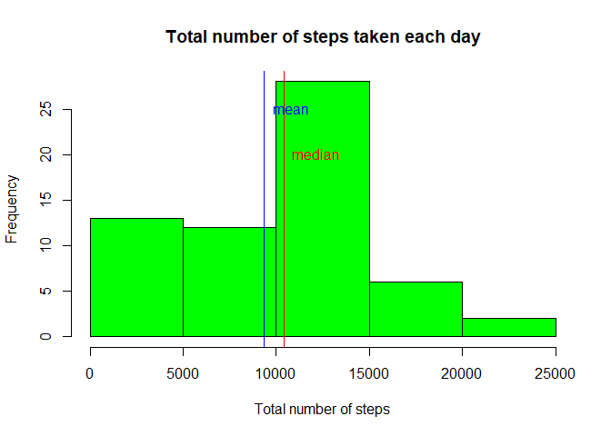

```r
z.plot1<-function(){

        hist(a$total_step,col="green",main="Total number of steps taken each day",xlab="Total number of steps")
        abline(v=median(a$total_step), col="red")
        abline(v=mean(a$total_step),col="blue")
        text(mean(a$total_step),25,labels="mean", pos=4, col="blue")
        text(median(a$total_step),20,labels="median", pos=4, col="red")


}
z.plot1()
```

```r
mean <- mean(a$total_step)
median <- median(a$total_step)
```

The mean of the total number of steps taken per day is 9354.2295082. The median of the total number of steps taken per day is 10395.

# What is the average daily activity pattern?

## 1. Make a time series plot (i.e. type = “l”) of the 5-minute interval (x-axis) and the average number of steps taken, averaged across all days (y-axis)

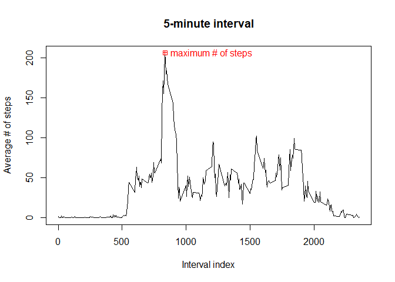

```r
activity %>% group_by(interval) %>% summarise(avg_step = mean(steps, na.rm = TRUE)) ->b

plot(b$interval,b$avg_step, type="l", ylab="Average # of steps", xlab="Interval index", main="5-minute interval")
y<-max(b$avg_step)
x<-subset(b,avg_step==y, select="interval")
points(x,y,col="red",pch=12)
text(x,y,labels="maximum # of steps", pos=4, col="red")
```

## 2. Which 5-minute interval, on average across all the days in the dataset, contains the maximum number of steps?

Interval 835 on average across all the days contains the maximum number of steps 206.1698113.

# Imputing missing values

## 1. Calculate and report the total number of missing values in the dataset (i.e. the total number of rows with NAs)

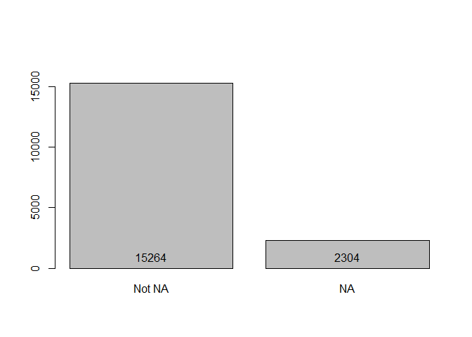

```r
activity %>% group_by(na=is.na(steps)) %>% summarise(count = n()) ->c
barplot(c$count,names.arg=c("Not NA","NA"),ylim=range(0,nrow(activity)))

na <- subset(c, na,select="count")
notna <- subset(c, !na,select="count")
text(.7,0,labels=notna, pos=3)
text(1.9,0,labels=na, pos=3)
```

## 2. Devise a strategy for filling in all of the missing values in the dataset.

I’ll use the average number of steps taken, averaged across all days (y-axis) to impute the missing values at each correspoinding interval.

## 3. Create a new dataset dfinal that is equal to the original dataset but with the missing data filled in.

```r
merge(activity, b, by="interval") -> d
d[is.na(d["steps"]),]->d1
mutate(d1,steps=avg_step)->d1m
d[!is.na(d["steps"]),]->d2
rbind(d1m,d2)->dfinal
```

## 4. Make a histogram of the total number of steps taken each day and Calculate and report the mean and median total number of steps taken per day

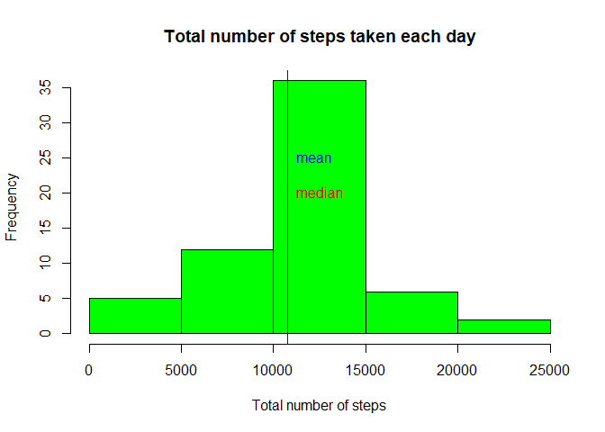

```r
z.plot2<-function(){

        dfinal %>% group_by(date) %>% summarise(total_step = sum(steps, na.rm = TRUE)) ->dfinal2

        p2<-hist(dfinal2$total_step,col="green",main="Total number of steps taken each day",xlab="Total number of steps")
        abline(v=median(dfinal2$total_step), col="red")
        abline(v=mean(dfinal2$total_step),col="blue")

        text(mean(dfinal2$total_step),25,labels="mean", pos=4, col="blue")
        text(median(dfinal2$total_step),20,labels="median", pos=4, col="red")
}

z.plot2()
```

## Do these values differ from the estimates from the first part of the assignment?

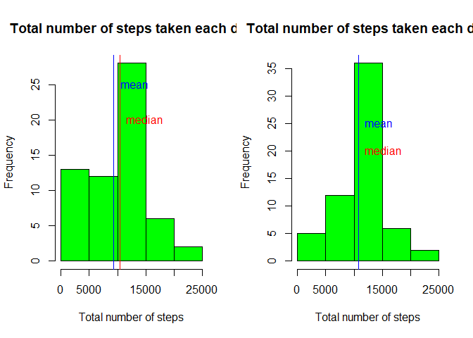

```r
par(mfrow=c(1,2))
z.plot1()
z.plot2()
```

# Are there differences in activity patterns between weekdays and weekends?

## 1. Create a new factor variable in the dataset with two levels – “weekday” and “weekend” indicating whether a given date is a weekday or weekend day.

```r
mutate(dfinal, weekday=weekdays(date))-> wd
wd[wd["weekday"] == "Saturday" | wd["weekday"] =="Sunday",]->weekend
mutate(weekend, weekday="weekend")-> weekend
wd[wd["weekday"]!="Saturday" & wd["weekday"]!="Sunday",]->weekday
mutate(weekday, weekday="weekday")-> weekday
rbind(weekday,weekend)->wdfinal

wdfinal$weekday <- as.factor(wdfinal$weekday)
```

## 2. Make a panel plot containing a time series plot (i.e. type = “l”) of the 5-minute interval (x-axis) and the average number of steps taken, averaged across all weekday days or weekend days (y-axis).

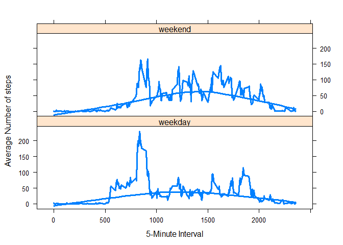

```r
wdfinal %>% group_by(interval, weekday) %>% summarise(avg_step = mean(steps, na.rm = TRUE)) ->wdfinal2


xyplot(avg_step ~ interval | weekday ,wdfinal2, ylab="Average Number of steps", xlab="5-Minute Interval",layout=c(1,2), type=c('l','smooth'), lwd=3)
```

As the plot shows, the individual works out more at weekend than weekdays in general, and less around 8 a.m.at weekend than during weekdays, due to commute to work in the morning.